# Breast Cancer Data Analysis

```r
library(corrplot)
library(RColorBrewer)
library(caret)
library(kernlab)
library(tidyverse)
library(mice)
library(extrafont)

font_import(pattern = 'Lato')
```

```
## Importing fonts may take a few minutes, depending on the number of fonts and the speed of the system.
## Continue? [y/n]
```

```r
theme_set(theme_bw())
theme_update(text = element_text(family='Lato Light'),
             plot.title = element_text(size = 16,
                                       face = "bold",
                                       hjust = 0.5,
                                       lineheight = 1.2),
             plot.margin = margin(10, 10, 10, 10, "pt"),
             strip.text.x = element_text(size = 12),
             axis.title.x = element_text(size = 14),
             axis.title.y = element_text(size = 14),
             axis.text.x = element_text(size = 11,
                                        vjust = 0.5),
             axis.text.y = element_text(size = 11))
```

```r
filename <- 'breast-cancer-wisconsin.data'
df.orig <- read_delim(
  filename,
  delim = ',',
  col_names=c('ID','Clump_Thick',
              'Unif_Cell_Sz',
              'Unif_Cell_Shp',
              'Marg_Adh',
              'Sngl_Epth_Cell_Sz',
              'Bare_Nucl','Bland_Chrmt',
              'Norm_Nucl', 'Mitoses',
              'Class'),
  col_types = cols(
    ID=col_character(),
    Clump_Thick=col_integer(),
    Unif_Cell_Sz=col_integer(),
    Unif_Cell_Shp=col_integer(),
    Marg_Adh=col_integer(),
    Sngl_Epth_Cell_Sz=col_integer(),
    Bare_Nucl=col_integer(),
    Bland_Chrmt=col_integer(),
    Norm_Nucl=col_integer(),
    Mitoses=col_integer(),
    Class=col_factor()),
  na='?')
```

All the na values are in Bare_Nucl

```r
# where are the na values?
sapply(df.orig, function(x) sum(is.na(x)))
```

```
##                ID       Clump_Thick      Unif_Cell_Sz     Unif_Cell_Shp
##                 0                 0                 0                 0
##          Marg_Adh Sngl_Epth_Cell_Sz         Bare_Nucl       Bland_Chrmt
##                 0                 0                16                 0
##         Norm_Nucl           Mitoses             Class
##                 0                 0                 0
```

Find patterns in missing data

```r
# get the summary statistics for Bare_Nucl
summary(df.orig$Bare_Nucl)
```

```
##    Min. 1st Qu.  Median    Mean 3rd Qu.    Max.    NA's
##   1.000   1.000   1.000   3.545   6.000  10.000      16
```

```r
# is there any pattern in the missing data?
# e.g. high/low values in other variables
df.missing = df.orig[is.na(df.orig$Bare_Nucl),]
summary(df.missing)
```

```
##       ID             Clump_Thick     Unif_Cell_Sz   Unif_Cell_Shp
##  Length:16          Min.   :1.000   Min.   :1.000   Min.   :1.000
##  Class :character   1st Qu.:1.000   1st Qu.:1.000   1st Qu.:1.000
##  Mode  :character   Median :3.000   Median :1.000   Median :2.500
##                     Mean   :3.375   Mean   :2.438   Mean   :2.875
##                     3rd Qu.:5.000   3rd Qu.:4.000   3rd Qu.:4.250
##                     Max.   :8.000   Max.   :8.000   Max.   :8.000
##
##     Marg_Adh     Sngl_Epth_Cell_Sz   Bare_Nucl    Bland_Chrmt
##  Min.   :1.000   Min.   :1.000     Min.   : NA   Min.   :1.000
##  1st Qu.:1.000   1st Qu.:2.000     1st Qu.: NA   1st Qu.:2.000
##  Median :1.000   Median :2.000     Median : NA   Median :2.500
##  Mean   :1.812   Mean   :2.438     Mean   :NaN   Mean   :3.125
##  3rd Qu.:1.000   3rd Qu.:2.000     3rd Qu.: NA   3rd Qu.:3.250
##  Max.   :9.000   Max.   :7.000     Max.   : NA   Max.   :7.000
##                                    NA's   :16
##    Norm_Nucl        Mitoses  Class
##  Min.   : 1.00   Min.   :1   2:14
##  1st Qu.: 1.00   1st Qu.:1   4: 2
##  Median : 1.00   Median :1
##  Mean   : 2.75   Mean   :1
##  3rd Qu.: 3.00   3rd Qu.:1
##  Max.   :10.00   Max.   :1
##
```

There are a disproportionate number of 2s compared to 4s in Class. 2 means that the tumour was classified as benign. This could explain the missing data. If the growth was benign, it is possible that data for bare nuclei (which occurs when a cell has little or no cytoplasm - typically seen in cell degeneration) was simply absent in the analyses.

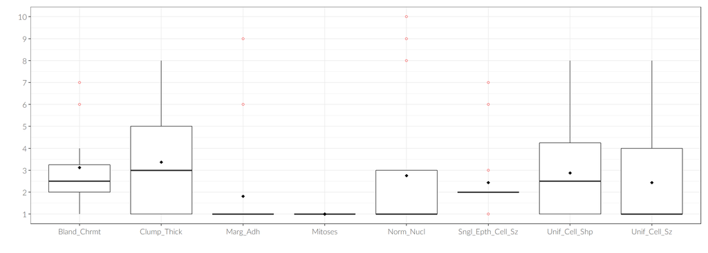

```r
# boxplot of other variables
df.missing[-c(1,7,11)] %>%
  gather(key = 'Variable', value = 'Value') %>%
  ggplot(aes(x=Variable, y=Value)) +
  geom_boxplot(outlier.colour='red',
               outlier.shape=1) +
  scale_y_continuous(breaks=1:10) +
  stat_summary(fun.y="mean",
               geom="point",
               shape=18, size=2) +
  labs(y='', x='')
```

Clump_Thick and Unif_Cell_Shp appear to have fairly normal distribution mean and median are quite close together range of values (1 to 8) is similar to the original range (1 to 10). Most of the other variables show a similar range of values to the original data. Only Mitoses shows consistently low values (all values are 1).

### MEAN/MODE IMPUTATION

```r
set.seed(123)

df.mm = df.orig
df.mm$Bare_Nucl[is.na(df.mm$Bare_Nucl)] = as.integer(round(mean(
                                                      df.mm$Bare_Nucl,
                                                      na.rm=TRUE), 0))

summary(df.mm$Bare_Nucl)
```

```
##    Min. 1st Qu.  Median    Mean 3rd Qu.    Max.
##   1.000   1.000   1.000   3.555   5.000  10.000
```

```r
# imputed values
df.mm$Bare_Nucl[is.na(df.orig$Bare_Nucl)]
```

```
##  [1] 4 4 4 4 4 4 4 4 4 4 4 4 4 4 4 4
```

### REGRESSION IMPUTATION

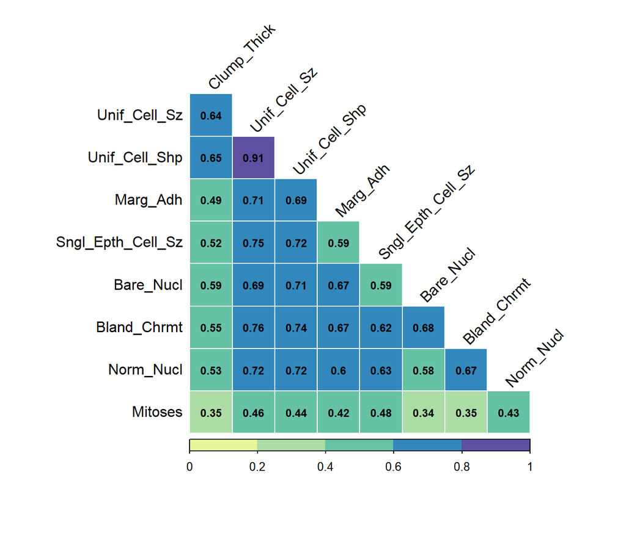

```r
df.reg = df.orig

# get correlation plot to see which vars are associated with Bare_Nucl
# don't include ID and Class in corr
cancer_corr = cor(df.reg[-c(1,11)], use='complete.obs')
corrplot(cancer_corr, col = brewer.pal(10, 'Spectral'),
         number.cex = 0.75, type='lower', method = 'color',
         addCoef.col = 'black', outline = 'white',
         tl.col="black", tl.srt=45, diag = FALSE,
         cl.lim = c(0, 1))
```

Unif_Cell_Shp appears to have the strongest correlation with Bare_Nucl. Unif_Cell_Sz, Bland_Chrmt and Marg_Adh also show high correlation with Bare_Nucl.

```r
# build linear model using Unif_Cell_Shp, Unif_Cell_Sz, Bland_Chrmt and
# Marg_Adh to predict Bare_Nucl
cr.lm <- lm(Bare_Nucl~ Unif_Cell_Shp+Unif_Cell_Sz+Bland_Chrmt+Marg_Adh,
            df.reg)

summary(cr.lm)
```

```
##
## Call:
## lm(formula = Bare_Nucl ~ Unif_Cell_Shp + Unif_Cell_Sz + Bland_Chrmt +
##     Marg_Adh, data = df.reg)
##
## Residuals:
##     Min      1Q  Median      3Q     Max
## -9.5362 -0.8129 -0.4501  0.5509  8.1871
##
## Coefficients:
##                 Estimate Std. Error t value Pr(>|t|)
## (Intercept)   -0.0430206  0.1544656  -0.279    0.781
## Unif_Cell_Shp  0.4294069  0.0723545   5.935 4.70e-09 ***
## Unif_Cell_Sz  -0.0003026  0.0739881  -0.004    0.997
## Bland_Chrmt    0.3627082  0.0585593   6.194 1.02e-09 ***
## Marg_Adh       0.3386468  0.0461395   7.340 6.15e-13 ***
## ---
## Signif. codes:  0 '***' 0.001 '**' 0.01 '*' 0.05 '.' 0.1 ' ' 1
##
## Residual standard error: 2.324 on 678 degrees of freedom
##   (16 observations deleted due to missingness)
## Multiple R-squared:  0.5957, Adjusted R-squared:  0.5934
## F-statistic: 249.8 on 4 and 678 DF,  p-value: < 2.2e-16
```

```r
# drop any nonsignificant predictors
cr.lm = update(cr.lm, . ~ . - Unif_Cell_Sz)

summary(cr.lm)
```

```
##
## Call:
## lm(formula = Bare_Nucl ~ Unif_Cell_Shp + Bland_Chrmt + Marg_Adh,
##     data = df.reg)
##
## Residuals:
##     Min      1Q  Median      3Q     Max
## -9.5362 -0.8128 -0.4501  0.5508  8.1872
##
## Coefficients:
##               Estimate Std. Error t value Pr(>|t|)
## (Intercept)   -0.04296    0.15354  -0.280     0.78
## Unif_Cell_Shp  0.42918    0.04758   9.021  < 2e-16 ***
## Bland_Chrmt    0.36265    0.05680   6.385 3.17e-10 ***
## Marg_Adh       0.33861    0.04524   7.486 2.22e-13 ***
## ---
## Signif. codes:  0 '***' 0.001 '**' 0.01 '*' 0.05 '.' 0.1 ' ' 1
##
## Residual standard error: 2.322 on 679 degrees of freedom
##   (16 observations deleted due to missingness)
## Multiple R-squared:  0.5957, Adjusted R-squared:  0.594
## F-statistic: 333.5 on 3 and 679 DF,  p-value: < 2.2e-16
```

```r
df.reg$Bare_Nucl[is.na(df.orig$Bare_Nucl)] = round(predict(cr.lm,
                                                        df.missing[-7]),
                                                        0)

summary(df.reg$Bare_Nucl)
```

```
##    Min. 1st Qu.  Median    Mean 3rd Qu.    Max.
##   1.000   1.000   1.000   3.529   6.000  10.000
```

```r
# imputed values
df.reg$Bare_Nucl[is.na(df.orig$Bare_Nucl)]
```

```
##  [1] 5 8 1 2 2 2 3 2 2 6 1 2 6 2 1 1
```

### REGRESSION IMPUTATION WITH PERTURBATION

```r
set.seed(123)

df.regP = df.orig
post <- make.post(df.regP)
post['Bare_Nucl'] <- "imp[[j]][,i] <- as.integer(round(
                                            squeeze(imp[[j]][,i],
                                            c(1, 10)),0))"

imp <- mice(df.regP, method="norm.nob", m=1,
            maxit=1, post=post)
df.regP <- complete(imp)

summary(df.regP$Bare_Nucl)
```

```
##    Min. 1st Qu.  Median    Mean 3rd Qu.    Max.
##   1.000   1.000   1.000   3.518   5.500  10.000
```

```r
# imputed values
df.regP$Bare_Nucl[is.na(df.orig$Bare_Nucl)]
```

```
##  [1] 8 4 1 1 5 2 1 3 1 4 1 1 1 1 1 3
```

### IMPUTATION MODEL COMPARISON

```r
# create 60%-40% train-test split
trainTest <- function(df) {
  set.seed(123)
  df <- subset(df, select=-c(ID))
  train <- createDataPartition(df$Class,
                               p=0.6,
                               list=FALSE,
                               times=1)
  df.train <- df[train,]
  df.test <- df[-train,]

  return(list('train'=df.train, 'test'=df.test))
}

trctrl <- trainControl(method="cv", number=10)

tg <- expand.grid(C = c(0.01, 0.1, 1, 10, 100))

getModel <- function(train, test, formula) {
  model <- train(formula, train, method="svmLinear",
                 tuneGrid=tg, trControl=trctrl,
                 tuneLength=10)

  print(model$finalModel)
  pred <- predict(model, test[-10])
  confusionMatrix(pred, test$Class)
}

#
## IMPUTATION MODELS

# don't include ID col
trainTest.mm <- trainTest(df.mm)
trainTest.reg <- trainTest(df.reg)
trainTest.regP <- trainTest(df.regP)

# MEAN/MODE IMPUTATION
getModel(trainTest.mm$train, trainTest.mm$test, Class~.)
```

```
## Support Vector Machine object of class "ksvm"
##
## SV type: C-svc  (classification)
##  parameter : cost C = 0.1
##
## Linear (vanilla) kernel function.
##
## Number of Support Vectors : 47
##
## Objective Function Value : -3.7702
## Training error : 0.035714
```

```
## Confusion Matrix and Statistics
##
##           Reference
## Prediction   2   4
##          2 178   3
##          4   5  93
##
##                Accuracy : 0.9713
##                  95% CI : (0.9443, 0.9875)
##     No Information Rate : 0.6559
##     P-Value [Acc > NIR] : <2e-16
##
##                   Kappa : 0.9368
##
##  Mcnemar's Test P-Value : 0.7237
##
##             Sensitivity : 0.9727
##             Specificity : 0.9688
##          Pos Pred Value : 0.9834
##          Neg Pred Value : 0.9490
##              Prevalence : 0.6559
##          Detection Rate : 0.6380
##    Detection Prevalence : 0.6487
##       Balanced Accuracy : 0.9707
##
##        'Positive' Class : 2
##
```

```r
# REGRESSION IMPUTATION
getModel(trainTest.reg$train, trainTest.reg$test, Class~.)
```

```
## Support Vector Machine object of class "ksvm"
##
## SV type: C-svc  (classification)
##  parameter : cost C = 10
##
## Linear (vanilla) kernel function.
##
## Number of Support Vectors : 35
##
## Objective Function Value : -297.7088
## Training error : 0.028571
```

```
## Confusion Matrix and Statistics
##
##           Reference
## Prediction   2   4
##          2 178   5
##          4   5  91
##
##                Accuracy : 0.9642
##                  95% CI : (0.9351, 0.9827)
##     No Information Rate : 0.6559
##     P-Value [Acc > NIR] : <2e-16
##
##                   Kappa : 0.9206
##
##  Mcnemar's Test P-Value : 1
##
##             Sensitivity : 0.9727
##             Specificity : 0.9479
##          Pos Pred Value : 0.9727
##          Neg Pred Value : 0.9479
##              Prevalence : 0.6559
##          Detection Rate : 0.6380
##    Detection Prevalence : 0.6559
##       Balanced Accuracy : 0.9603
##
##        'Positive' Class : 2
##
```

```r
# REGRESSION WITH PERTURBATION IMPUTATION
getModel(trainTest.regP$train, trainTest.regP$test, Class~.)
```

```
## Support Vector Machine object of class "ksvm"
##
## SV type: C-svc  (classification)
##  parameter : cost C = 0.01
##
## Linear (vanilla) kernel function.
##
## Number of Support Vectors : 81
##
## Objective Function Value : -0.6041
## Training error : 0.038095
```

```
## Confusion Matrix and Statistics
##
##           Reference
## Prediction   2   4
##          2 179   2
##          4   4  94
##
##                Accuracy : 0.9785
##                  95% CI : (0.9538, 0.9921)
##     No Information Rate : 0.6559
##     P-Value [Acc > NIR] : <2e-16
##
##                   Kappa : 0.9526
##
##  Mcnemar's Test P-Value : 0.6831
##
##             Sensitivity : 0.9781
##             Specificity : 0.9792
##          Pos Pred Value : 0.9890
##          Neg Pred Value : 0.9592
##              Prevalence : 0.6559
##          Detection Rate : 0.6416
##    Detection Prevalence : 0.6487
##       Balanced Accuracy : 0.9787
##
##        'Positive' Class : 2
##
```